# Marine Ecological Modelling Global Climate Change

Vector polygon data can be stored in a **shapefile** format.

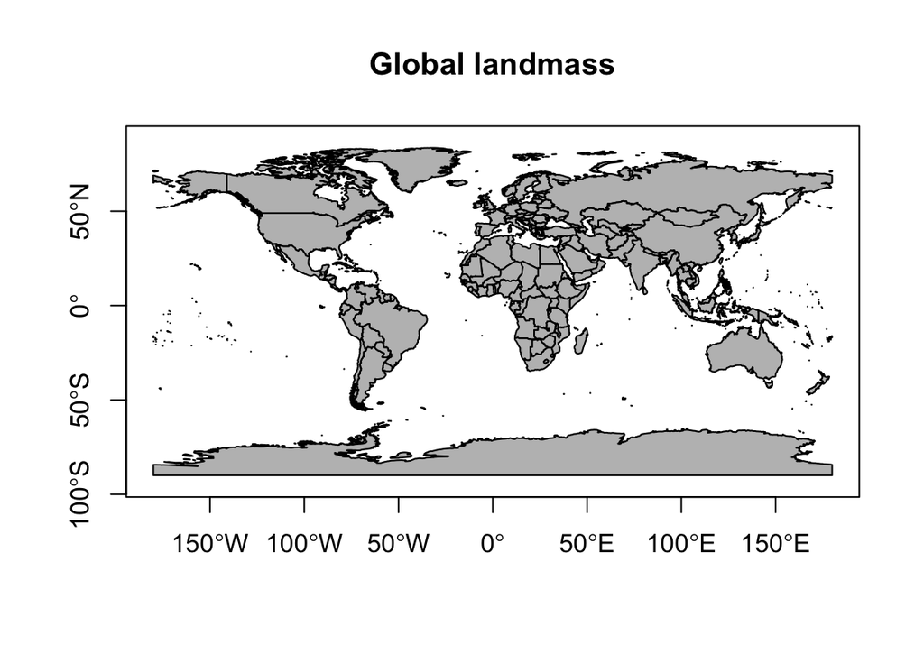

```r
# load a line vector shapefile
landMass <- shapefile('Data/vectorShapefiles/globalLandmass/world.shp')
# plot spatial polygon vector with a title
plot(landMass, main = 'Global landmass', col='gray', axes=TRUE)
```

To overlay points from with vector layers in a plot use **points**.

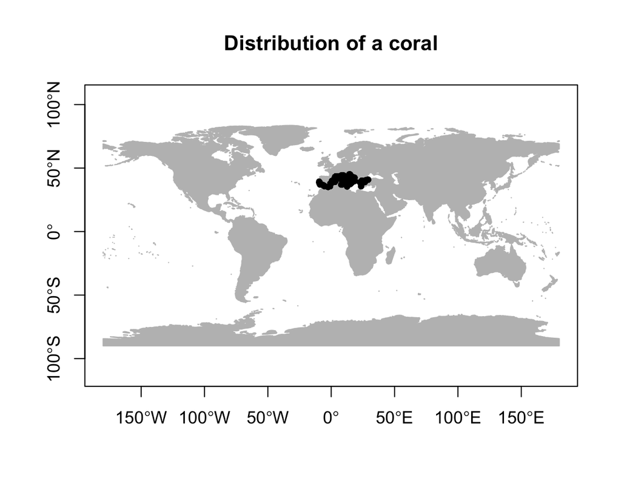

```r
plot(landMass, main='Distribution of a coral', col='Gray', border='Gray', axes=TRUE)
points(distributionRecords, pch=20)
```

To overlay multiple vector layers in a plot use the **add=TRUE** argument.

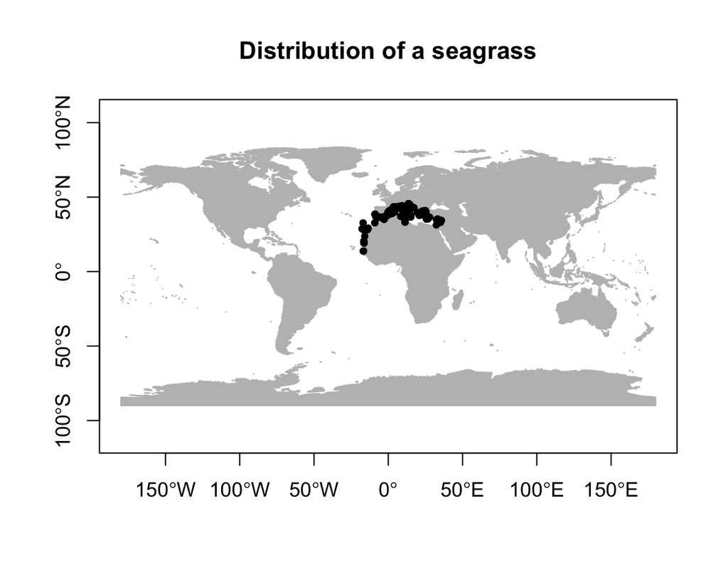

```r
seagrass <- shapefile("Data/vectorShapefiles/seagrass/cymodoceaNodosa.shp")
plot(landMass, main='Distribution of a seagrass', col='Gray', border='Gray', axes=TRUE)
plot(seagrass, pch=20, add=TRUE)
```

### Challenge 2.1

The main objective of this challenge is to **plot** a text file with the distribution of a coral species.  
The plot must include the landmass shapefile of the world.

Go to Menu -> Sessions -> Set the working directory -> My directory of Sessions_[P]  
Files to use:  
"Data/dataBases/MergedCoordinates.csv"  
"Data/vectorShapefiles/globalLandmass/world.shp"  
Functions:  
library(raster)  
shapefile(path)  
plot(object)  
points(object)

## Vector data operations

Operations that change the geometry of spatial vector objects.

### Crop vector data

```r
# read landmass from an R package
globalLandmass <- shapefile('Data/vectorShapefiles/globalLandmass/world.shp')

# generate an extent object (region of interest, xmin,xmax,ymin,ymax)
westAfricaExtent <- extent(-30, 22, -37.5, 36)
```

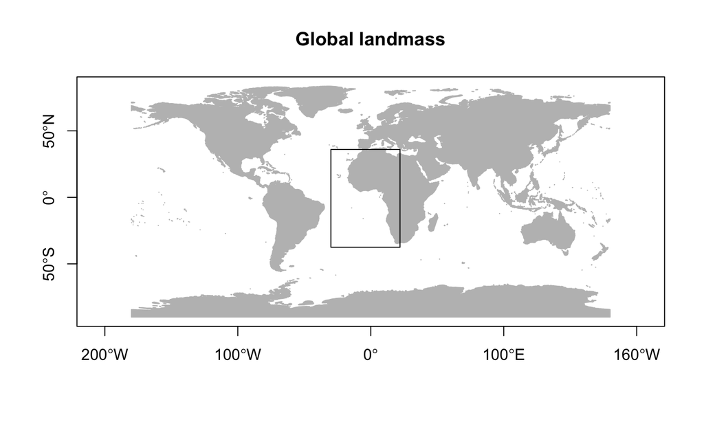

```r
plot(globalLandmass, main = 'Global landmass', col='gray', border='gray', axes = TRUE)
plot(westAfricaExtent, border='black',add=TRUE)
```

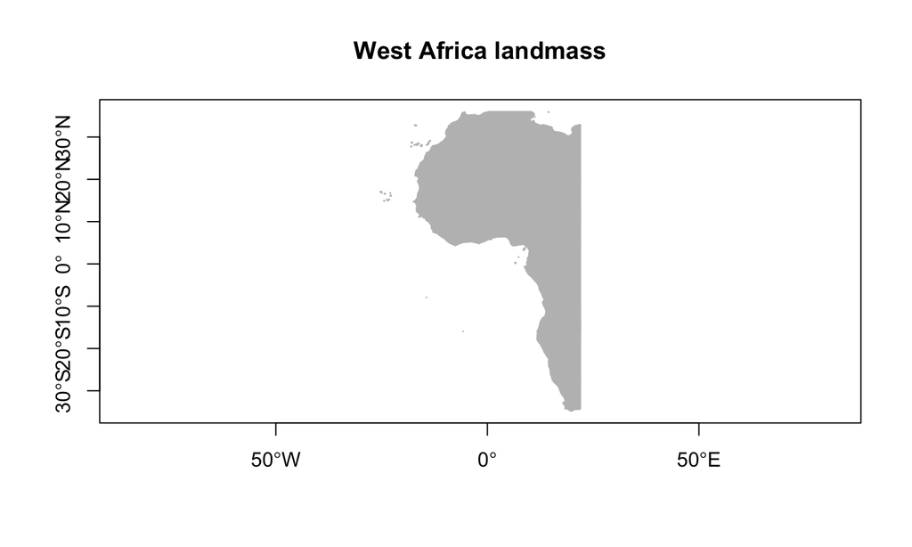

```r
westAfricaLandmass <- crop(globalLandmass,westAfricaExtent)
plot(westAfricaLandmass, main = 'West Africa landmass', col='gray', border='gray',axes = TRUE)
```

### Challenge 2.2

The main objective of this challenge is to **crop** a global map to the Azores islands region and **plot** it.

Go to Menu -> Sessions -> Set the working directory -> My directory of Sessions_[P]  
Important information:  
Min. Longitude: -36  
Max. Longitude: -18  
Min. Latitude: 34  
Max. Latitude: 42  
Files to use: "Data/vectorShapefiles/globalLandmass/world.shp"  
Packages:  
library(raster)  
shapefile(path)  
extent(object)  
crop(object)  
plot(object)

## Raster data

## Raster data

Raster data comes as an image representing a portion of the earth, using a regular grid. The **raster package** deals with multi-layer data using a **RasterStack**.

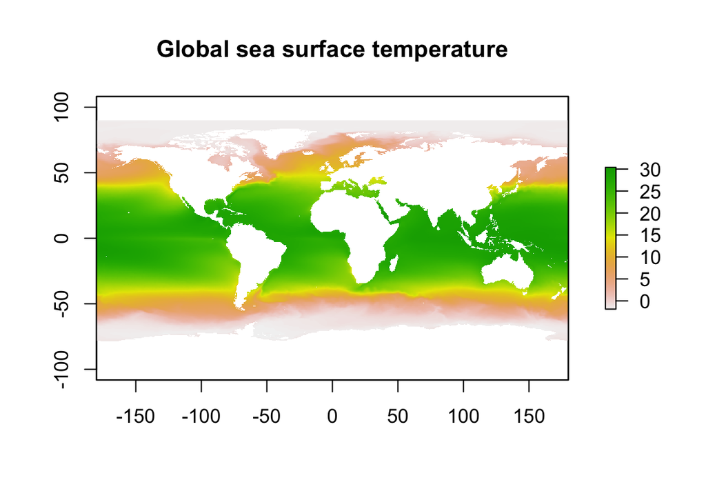

```r
# Open a raster layer with the global sst
SST <- raster('Data/rasterLayers/Climate/Present/OceanTemperature Surface Pred Mean.tif')
# Plot a raster layer
plot(SST , main='Global sea surface temperature')
```

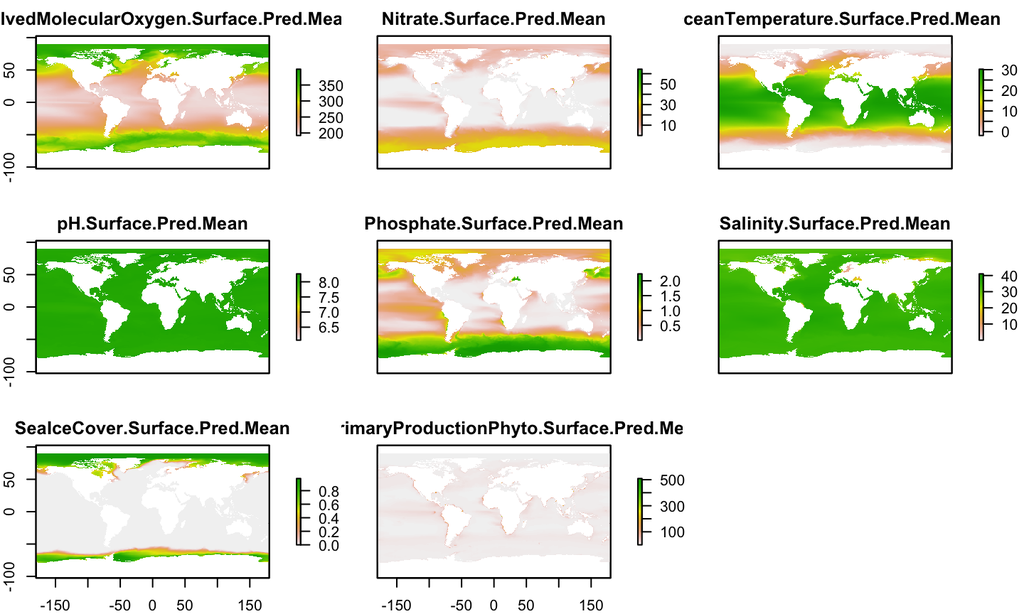

```r
# Open all layers inside a folder
environmentalData <- stackDirectory('Data/rasterLayers/Climate/Present/')
# Plot raster layers
plot(environmentalData)
```

### Challenge 2.3

The main objective of this challenge is to make one **plot** of the global SST.

Go to Menu -> Sessions -> Set the working directory -> My directory of Sessions_[P]  
Files to use:  
"Data/rasterLayers/Climate/Present/OceanTemperature Surface Pred Mean.tif"  
Packages:  
library(raster)  
raster(path)  
plot(object)

## Raster data operations

### Crop raster data

```r
# load the raster layer
presentSST <- raster('Data/rasterLayers/Climate/Present/OceanTemperature Surface Pred Mean.tif')

# define the extent to crop [xmin, xmax, ymin, ymax]
westAfricaExtent <- extent(-30, 22, -37.5, 36)
```

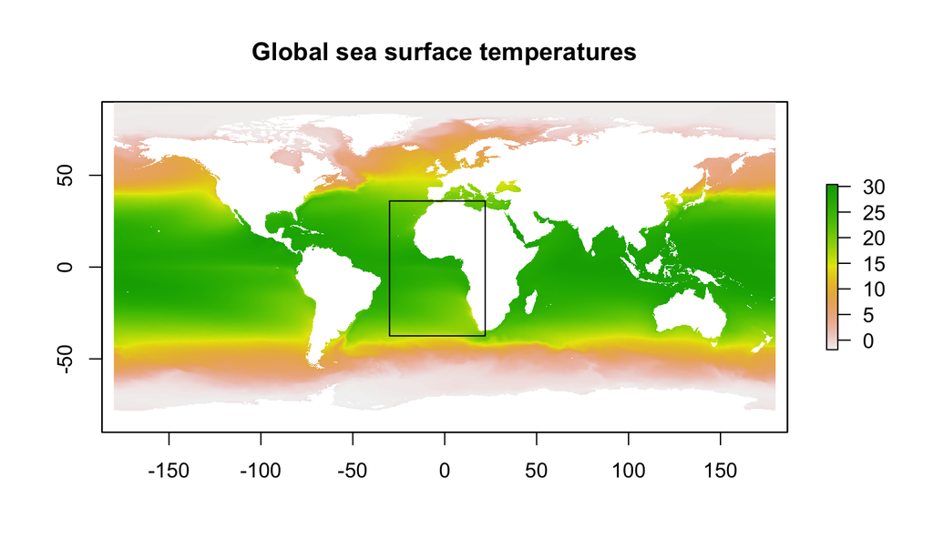

```r
# plot temperature
plot(presentSST, main='Global sea surface temperatures')
# plot region of interest
plot(westAfricaExtent, add=TRUE)
```

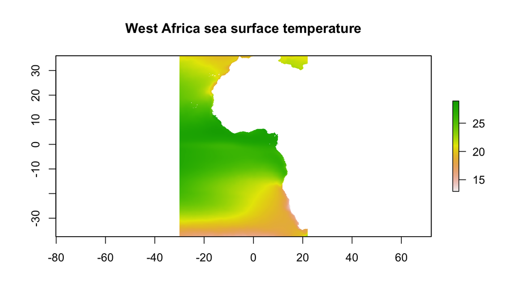

```r
# crop with polygon (region)
westAfricaPresentSST <- crop(SST,westAfricaExtent)
plot(westAfricaPresentSST, main='West Africa sea surface temperature')
```

## Raster data operations

### Mask raster data

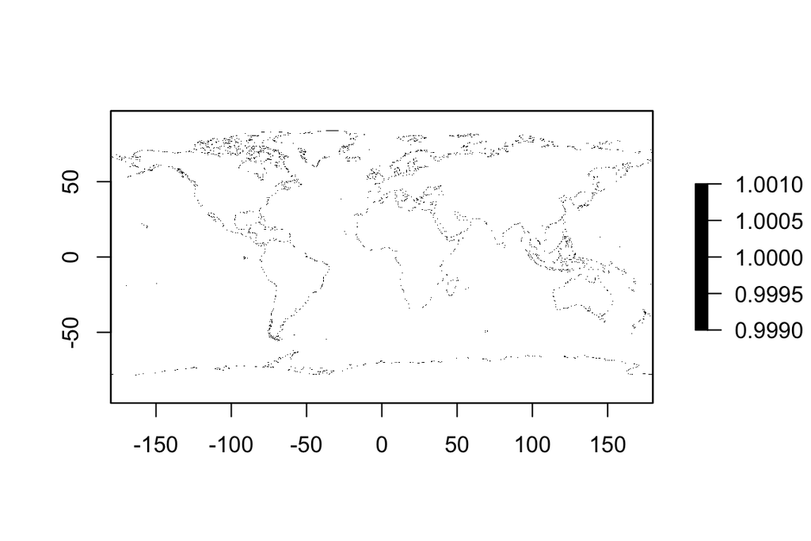

```r
# load the raster layer
SST <- raster('Data/rasterLayers/Climate/Present/OceanTemperature Surface Pred Mean.tif')
# load the raster mask
maskCoastal <- raster("Data/rasterLayers/CoastLine.tif")
# plot the raster mask
plot(maskCoastal, col="black")
```

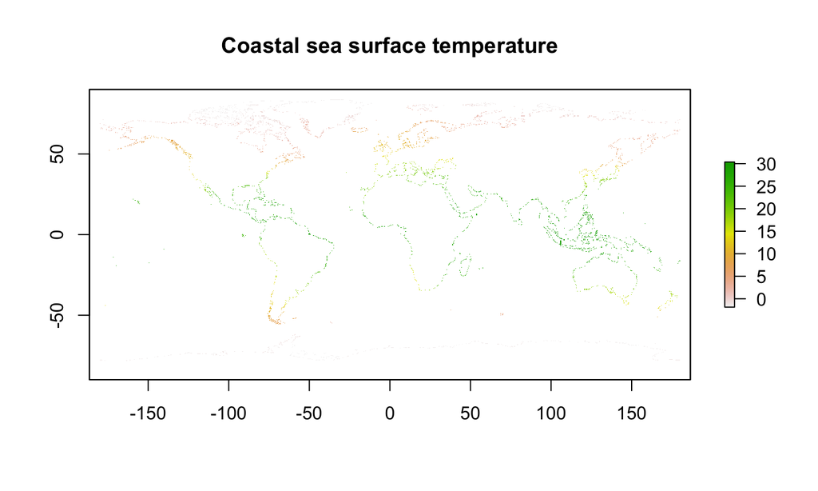

```r
# mask with raster layer (region)
CoastalSST <- mask(SST,maskCoastal)
# plot the masked layer
plot(CoastalSST, main='Coastal sea surface temperature')
```

### Challenge 2.4

The main objective of this challenge is to **crop** a global SST layers to the extent of Western Africa

Go to Menu -> Sessions -> Set the working directory -> My directory of Sessions_[P]  
Important information:  
Min. Longitude: -30  
Max. Longitude: 22  
Min. Latitude: -37.5  
Max. Latitude: 36  
File to use:  
"Data/rasterLayers/Climate/Present/OceanTemperature Surface Pred Mean.tif"  
Packages:  
library(raster)  
raster(path)  
extent(object)  
crop(object)  
plot(object)

## References

Global change impacts on biodiversity. Available at: https://damariszurell.github.io/HU-GCIB

Copyright (c) Earth Lab. Available at: https://www.earthdatascience.org.

Open Science for Synthesis: Gulf Research Program Workshop. Available at: https://github.com/NCEAS/oss-lessons

Gimond, M. (2019) Intro to GIS and Spatial Analysis. Available at: https://mgimond.github.io/Spatial/